# Week 9 Support Vector Machine (SVM)

March 13, 2020

## Overview

- Linearly separable data set and margin maximization
- Non-linearly separable data set soft margin classifier
- Soft margin classifier vs. hard margin classifier
- Kernel trick
- R/Python demo

## Support Vector Machine (SVM) Motivations

- Work with both linearly separable and linearly non-separable cases
- Maximize margin between categories
- Margins are only decided by the closest data points (support vectors)
  - SVM is robust for the outliers
  - Distance between data points and decision boundary indicates confidence of prediction

## Generative vs. Discriminative Algorithms

- Generative algorithm: infer the distribution that generate the observed data (joint probability)
  - Model probability of individual classes
  - Example: naive Bayes classifier,
- Discriminative algorithm: identify the decision boundary that separates different classes of the observed data. Make fewer assumptions about the data distribution than generative algorithm
  - Model the (hard or soft) decision boundary between different classes
  - Example: Support Vector Machine, logistic regression, decision tree induction
- Discriminative algorithm usually outperforms generative algorithm, given large enough training dataset

## Generative vs. Discriminative Algorithms (2)

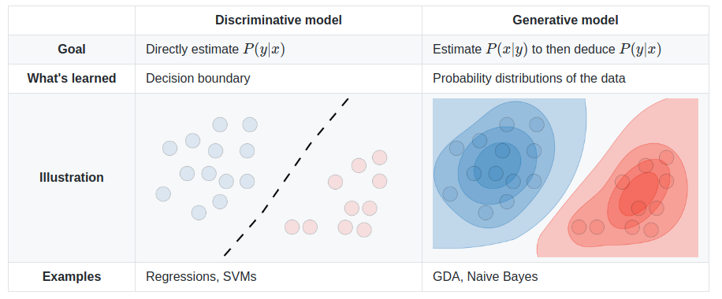

## SVM Hyperplane

- Linearly separable cases
- Maximize the margin between two parallel hyperplanes or minimize \(||\vec{w}||\)
- Support vectors: data points on those two parallel hyperplanes
  - Number of support vectors: complexity of models
- Prediction: hyperplane divides the feature space in half and we can classify new points by determining which side of the hyperplane they fall on

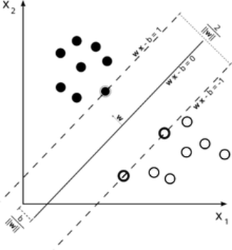

## Soft Margin Classifier

- Allow SVM to make a certain number of mistakes (\(\xi\))
- Keep margin as wide as possible so that rest of points can still be classified correctly
- \(y_i(\vec{w}\cdot\vec{x_i}+b)\geq1-\xi_i\)

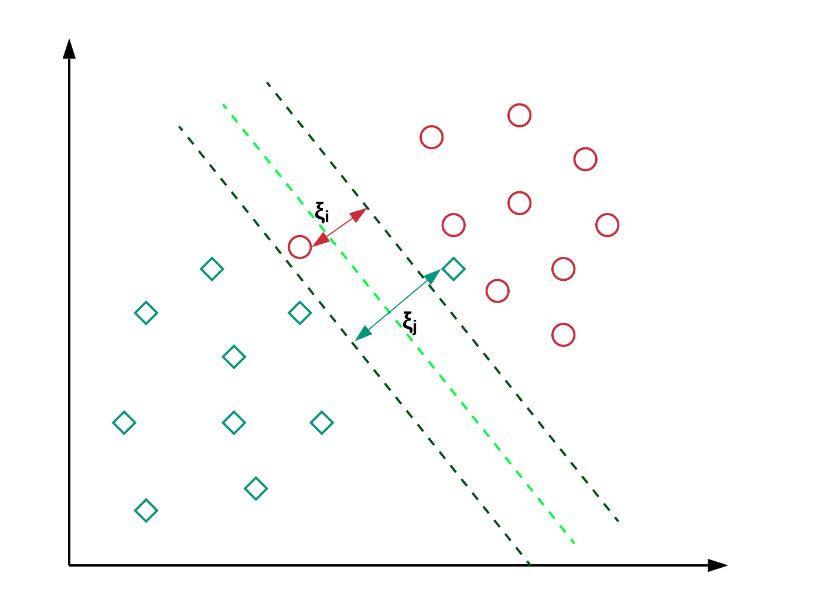

## Loss Function for SVM: Hinge Loss

- SVM loss leads to SVM model with the max-margin property
- Hinge/SVM loss
  - \(Hinge(y_i, \hat{y_i}) = \sum_i{max(0, 1-y_i*\hat{y_i})}\)
  - Scenario 1: \(y_i\) = -1, \(\hat{y_i}\) = 0.5, Hinge loss is 1.5
  - Scenario 2: \(y_i\) = -1, \(\hat{y_i}\) = -0.2, Hinge loss is 0.8
  - Scerario 3: \(y_i\) = -1, \(\hat{y_i}\) = -1.6, Hinge loss is 0
  - Therefore, Hinge loss penalizes those confident misclassification the most, and no penalty on the correct prediction

## Linearly Inseparable Challenge

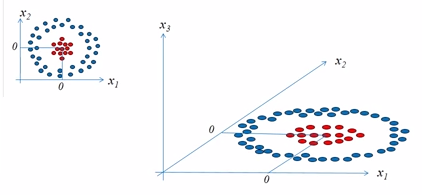

## Linearly Inseparable Challenge in a Higher Dimension

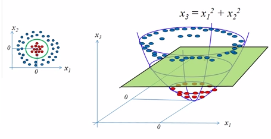

## Kernel Tricks

- Deal with classification that requires multiple (and nonlinear) boundaries
- Ideas: apply mathematical functions (kernels) to project linearly inseparable data points into higher dimensional space so that a hyperplane could be found to separate different classes
  - \(K(X_i, X_j) = \phi(X_i)\cdot\phi(X_j)\)
  - Why kernel function is a measure of similarity: the inner product above means the projection of \(\phi(X_i)\) on \(\phi(X_j)\) or how much overlap (or how similar) between \(\phi(X_i)\) and \(\phi(X_j)\)
  - Kernel function is a distance function on a higher dimension where hyperplane could be found.
  - Project the data to the higher dimension space in order to find hyperplane to separate classes without explicitly projecting with \(\phi\) function and calculate the distance in the projected higher dimesnion space

## Kernel Trick (2)

- The kernel trick avoids the explicit mapping that is needed to get linear learning algorithms to learn a nonlinear function or decision boundary.
- For all and in the input space , certain functions can be expressed as an inner product in another space . The function is often referred to as a kernel or a kernel function.

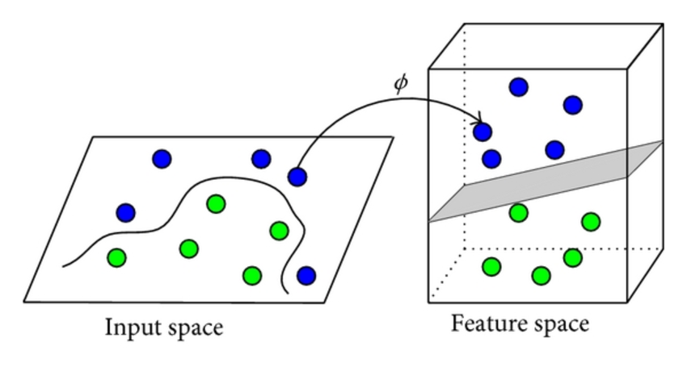

## Non-linear Kernel Functions

- SVM is about finding a hyperplane (through margin maximization) to separate different classes
- Kernel: find distance between data points on a higher dimensional space where a hyperplane could be identified
  - Radial basis function (RBF): project to infinite dimensional space \[ K(X_m, X_n) = exp(-\frac{||X_m - X_n||^2}{2\sigma^2}) \]
  - Polynomial kernel \[ K(X_m, X_n) = (X_m\cdot X_n + c)^d \]
  - Sigmoid kernel \[ K(X_m, X_n) = tanh(\kappa{X_m}\cdot{X_n}-\delta) \]
  - Commpare above distance functions with Manhattan and Euclidean distance functions in the current feature space prior to projecting to the higher dimensional space

## Data Preprocessing and Preparation

- Kernel functions are based on distance (distance on higher dimensions) and herefore require the following two preprocessing techniques
- Normalization
- Conversion from categorical attributes to numerical attributes
- Missing value imputation

## Model Parameters

- \(C\) (Cost): used for regularization, penalty associated with misclassification
  - Soft margin classification: allow a small numbr of misclassifications
  - Hyperparameter controling penalizing use of slack variables \(\xi\)
  - Higher \(C\): lower bias but risk of overfitting; higher complexity of decision boundary; higher number of support vectors; Lower \(C\): higher bias but lower variance
- Kernel function specific parameters
  - \(\gamma\) for RBF: contols the tradeoff between error due to bias and variance
    - \(k(X_m, X_n) = exp(-\gamma||X_m-X_n||^2)\)
    - Higher \(\gamma\) means higher risk of overfitting; lower \(\gamma\) means higher bias; moves in the same direction as \(C\)
  - Degree for Polynomial kernel
  - Scale for Polynomial kernel

## Properties of SVM

- Pros
  - Excellent performance for a wide variety of tasks because it can deal with nonlinear decision boundary
  - Provide confidence estimate (probability transformed from distance by proper mathematical functions)
  - Robust to noisy data
  - Flexible with data representation: numerical and categorical attributes
  - Effective with low sample/feature ratio data
- Cons
  - Lack of interpretability. Black-box model
  - Risk of choosing wrong kernel function

## Demo Dataset: Diabetes

```r
# install.packages("mlbench")
library(caret)
library(mlbench)
data("PimaIndiansDiabetes")
diabetes <- PimaIndiansDiabetes
str(diabetes)
```

```
## 'data.frame':    768 obs. of  9 variables:
##  $ pregnant: num  6 1 8 1 0 5 3 10 2 8 ...
##  $ glucose : num  148 85 183 89 137 116 78 115 197 125 ...
##  $ pressure: num  72 66 64 66 40 74 50 0 70 96 ...
##  $ triceps : num  35 29 0 23 35 0 32 0 45 0 ...
##  $ insulin : num  0 0 0 94 168 0 88 0 543 0 ...
##  $ mass    : num  33.6 26.6 23.3 28.1 43.1 25.6 31 35.3 30.5 0 ...
##  $ pedigree: num  0.627 0.351 0.672 0.167 2.288 ...
##  $ age     : num  50 31 32 21 33 30 26 29 53 54 ...
##  $ diabetes: Factor w/ 2 levels "neg","pos": 2 1 2 1 2 1 2 1 2 2 ...
```

```r
summary(diabetes)
```

```
##     pregnant         glucose         pressure         triceps
##  Min.   : 0.000   Min.   :  0.0   Min.   :  0.00   Min.   : 0.00
##  1st Qu.: 1.000   1st Qu.: 99.0   1st Qu.: 62.00   1st Qu.: 0.00
##  Median : 3.000   Median :117.0   Median : 72.00   Median :23.00
##  Mean   : 3.845   Mean   :120.9   Mean   : 69.11   Mean   :20.54
##  3rd Qu.: 6.000   3rd Qu.:140.2   3rd Qu.: 80.00   3rd Qu.:32.00
##  Max.   :17.000   Max.   :199.0   Max.   :122.00   Max.   :99.00
##     insulin           mass          pedigree           age
##  Min.   :  0.0   Min.   : 0.00   Min.   :0.0780   Min.   :21.00
##  1st Qu.:  0.0   1st Qu.:27.30   1st Qu.:0.2437   1st Qu.:24.00
##  Median : 30.5   Median :32.00   Median :0.3725   Median :29.00
##  Mean   : 79.8   Mean   :31.99   Mean   :0.4719   Mean   :33.24
##  3rd Qu.:127.2   3rd Qu.:36.60   3rd Qu.:0.6262   3rd Qu.:41.00
##  Max.   :846.0   Max.   :67.10   Max.   :2.4200   Max.   :81.00
##  diabetes
##  neg:500
##  pos:268
##
##
##
##
```

## Train and Test Data Partition

```r
library(caret)

set.seed(188)
train_index <- createDataPartition(diabetes$diabetes, p = 0.7, list = FALSE)

diabetes_train <- diabetes[train_index, ]
diabetes_test <- diabetes[-train_index, ]
```

## Demo: Train a Linear SVM Model

```r
set.seed(1818)
model_svm_linear <- train(diabetes ~ ., data = diabetes_train,
                          method = "svmLinear",
                          preProcess = c("center", "scale"),
                          trControl = trainControl(method = "boot", number = 25),
                          tuneGrid = expand.grid(C = seq(0, 1, 0.05)))
model_svm_linear
```

```
## Support Vector Machines with Linear Kernel
##
## 538 samples
##   8 predictor
##   2 classes: 'neg', 'pos'
##
## Pre-processing: centered (8), scaled (8)
## Resampling: Bootstrapped (25 reps)
## Summary of sample sizes: 538, 538, 538, 538, 538, 538, ...
## Resampling results across tuning parameters:
##
##   C     Accuracy   Kappa
##   0.00        NaN        NaN
##   0.05  0.7617913  0.4563736
##   0.10  0.7600813  0.4535191
##   0.15  0.7605774  0.4547414
##   0.20  0.7603933  0.4547595
##   0.25  0.7608005  0.4555370
##   0.30  0.7602058  0.4542325
##   0.35  0.7606215  0.4553087
##   0.40  0.7608251  0.4558617
##   0.45  0.7614284  0.4571489
##   0.50  0.7616284  0.4575390
##   0.55  0.7612264  0.4567524
##   0.60  0.7614284  0.4572411
##   0.65  0.7612264  0.4567524
##   0.70  0.7616284  0.4576311
##   0.75  0.7614264  0.4571425
##   0.80  0.7614361  0.4572523
##   0.85  0.7614264  0.4571425
##   0.90  0.7614264  0.4571425
##   0.95  0.7618265  0.4582616
##   1.00  0.7616043  0.4578212
##
## Accuracy was used to select the optimal model using the largest value.
## The final value used for the model was C = 0.95.
```

## Sensitivity Test for C

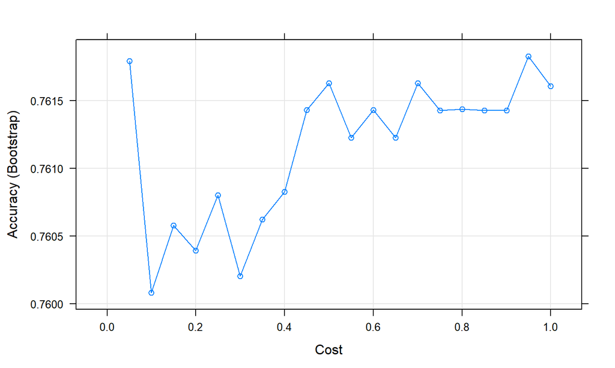

```r
plot(model_svm_linear)
```

## Linear SVM Performance Evaluation: Hold-out Method

```r
predict_svm_linear <- predict(model_svm_linear, newdata = diabetes_test)
confusionMatrix(predict_svm_linear, diabetes_test$diabetes)
```

```
## Confusion Matrix and Statistics
##
##           Reference
## Prediction neg pos
##        neg 134  36
##        pos  16  44
##
##                Accuracy : 0.7739
##                  95% CI : (0.7143, 0.8263)
##     No Information Rate : 0.6522
##     P-Value [Acc > NIR] : 4.208e-05
##
##                   Kappa : 0.4708
##  Mcnemar's Test P-Value : 0.008418
##
##             Sensitivity : 0.8933
##             Specificity : 0.5500
##          Pos Pred Value : 0.7882
##          Neg Pred Value : 0.7333
##              Prevalence : 0.6522
##          Detection Rate : 0.5826
##    Detection Prevalence : 0.7391
##       Balanced Accuracy : 0.7217
##
##        'Positive' Class : neg
##
```

## SVM with Non-linear Kernel: RBF

```r
model_svm_rbf <- train(diabetes ~ ., data = diabetes_train,
                       preProcess = c("center", "scale"),
                       tuneGrid = expand.grid(sigma = seq(0, 1, 0.1),
                                              C = seq(0, 1, 0.1)),
                       method = "svmRadial",
                       trControl = trainControl(method = "boot",
                                                number = 25))
```

```r
model_svm_rbf
```

```
## Support Vector Machines with Radial Basis Function Kernel
##
## 538 samples
##   8 predictor
##   2 classes: 'neg', 'pos'
##
## Pre-processing: centered (8), scaled (8)
## Resampling: Bootstrapped (25 reps)
## Summary of sample sizes: 538, 538, 538, 538, 538, 538, ...
## Resampling results across tuning parameters:
##
##   sigma  C    Accuracy   Kappa
##   0.0    0.0        NaN          NaN
##   0.0    0.1  0.6512478  0.000000000
##   0.0    0.2  0.6512478  0.000000000
##   0.0    0.3  0.6512478  0.000000000
##   0.0    0.4  0.6512478  0.000000000
##   0.0    0.5  0.6512478  0.000000000
##   0.0    0.6  0.6512478  0.000000000
##   0.0    0.7  0.6512478  0.000000000
##   0.0    0.8  0.6512478  0.000000000
##   0.0    0.9  0.6512478  0.000000000
##   0.0    1.0  0.6512478  0.000000000
##   0.1    0.0        NaN          NaN
##   0.1    0.1  0.7418882  0.356733112
##   0.1    0.2  0.7557221  0.417026383
##   0.1    0.3  0.7624871  0.441724027
##   0.1    0.4  0.7637365  0.447354762
##   0.1    0.5  0.7654968  0.452818008
##   0.1    0.6  0.7650638  0.453125832
##   0.1    0.7  0.7622742  0.448298608
##   0.1    0.8  0.7621327  0.449610338
##   0.1    0.9  0.7613368  0.449319274
##   0.1    1.0  0.7627733  0.453799274
##   0.2    0.0        NaN          NaN
##   0.2    0.1  0.7113016  0.240653384
##   0.2    0.2  0.7468655  0.386740621
##   0.2    0.3  0.7563845  0.422211842
##   0.2    0.4  0.7561906  0.427432365
##   0.2    0.5  0.7574452  0.434697605
```

[output cut: 81 more lines]

```
##   0.9    1.0  0.6935090  0.256805473
##   1.0    0.0        NaN          NaN
##   1.0    0.1  0.6512478  0.000000000
##   1.0    0.2  0.6534984  0.008371326
##   1.0    0.3  0.6561128  0.025257001
##   1.0    0.4  0.6587495  0.054359290
##   1.0    0.5  0.6653984  0.104219906
##   1.0    0.6  0.6686840  0.138038790
##   1.0    0.7  0.6695507  0.153397306
##   1.0    0.8  0.6734856  0.172778719
##   1.0    0.9  0.6785749  0.195043725
##   1.0    1.0  0.6804877  0.210732340
##
## Accuracy was used to select the optimal model using the largest value.
## The final values used for the model were sigma = 0.1 and C = 0.5.
```

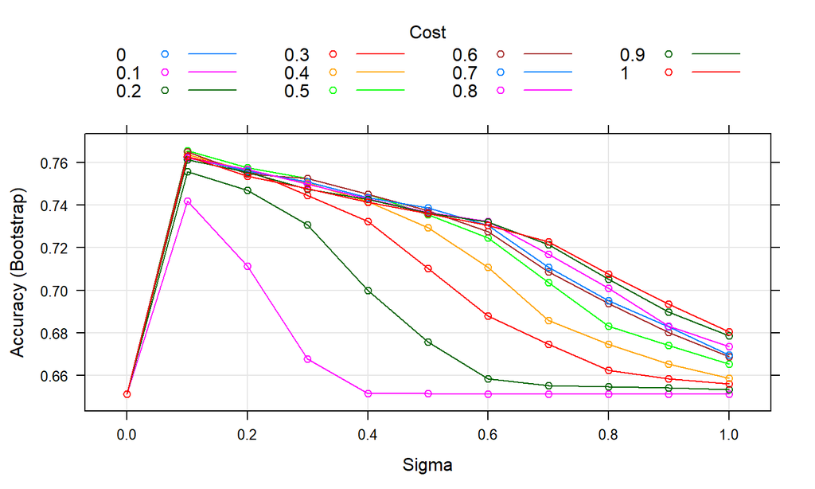

```r
plot(model_svm_rbf)
```

```r
predict_svm_rbf <- predict(model_svm_rbf, newdata = diabetes_test)
confusionMatrix(predict_svm_rbf, diabetes_test$diabetes)
```

```
## Confusion Matrix and Statistics
##
##           Reference
## Prediction neg pos
##        neg 131  43
##        pos  19  37
##
##                Accuracy : 0.7304
##                  95% CI : (0.6682, 0.7866)
##     No Information Rate : 0.6522
##     P-Value [Acc > NIR] : 0.006878
##
##                   Kappa : 0.3611
##  Mcnemar's Test P-Value : 0.003489
##
##             Sensitivity : 0.8733
##             Specificity : 0.4625
##          Pos Pred Value : 0.7529
##          Neg Pred Value : 0.6607
##              Prevalence : 0.6522
##          Detection Rate : 0.5696
##    Detection Prevalence : 0.7565
##       Balanced Accuracy : 0.6679
##
##        'Positive' Class : neg
##
```

## Compare the Performance of Multiple Algorithms

```r
model_comparison <- resamples(list(SVMLinear = model_svm_linear,
                                   SVMRBF = model_svm_rbf))
summary(model_comparison)
```

```
##
## Call:
## summary.resamples(object = model_comparison)
##
## Models: SVMLinear, SVMRBF
## Number of resamples: 25
##
## Accuracy
##                Min.   1st Qu.    Median      Mean   3rd Qu.      Max. NA's
## SVMLinear 0.6969697 0.7371134 0.7638191 0.7618265 0.7839196 0.8125000    0
## SVMRBF    0.7315789 0.7526316 0.7656250 0.7654968 0.7766497 0.8031088    0
##
## Kappa
##                Min.   1st Qu.    Median      Mean   3rd Qu.      Max. NA's
## SVMLinear 0.3432836 0.4134789 0.4659401 0.4582616 0.4931610 0.5637772    0
## SVMRBF    0.3760464 0.4141189 0.4633530 0.4528180 0.4885286 0.5365331    0
```

## Graphically Compare Performance

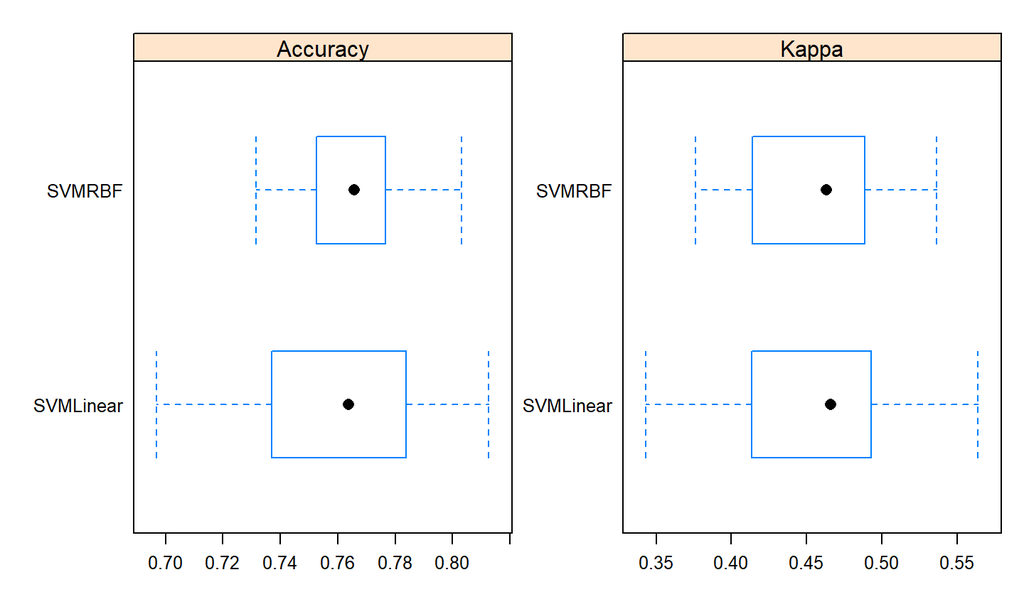

```r
scales <- list(x = list(relation = "free"),
               y = list(relation = "free"))

bwplot(model_comparison, scales = scales)
```

## Load in Libraries

```python
import numpy as np
import matplotlib.pyplot as plt
import pandas as pd
from sklearn.model_selection import train_test_split
from sklearn.preprocessing import StandardScaler
from sklearn import metrics
from sklearn.pipeline import make_pipeline
from sklearn.model_selection import ShuffleSplit
from sklearn.model_selection import cross_val_score
import seaborn as sns
from sklearn.decomposition import PCA
from sklearn.svm import SVC
from sklearn import svm
from sklearn import model_selection
from sklearn.model_selection import GridSearchCV
from matplotlib.legend_handler import HandlerLine2D
```

## Data Splitting and Preparation

```python
diabetes = r.diabetes
# diabetes = pd.read_csv("https://datahub.io/machine-learning/diabetes/r/diabetes.csv")
X = diabetes.drop("class", axis=1)
y = diabetes["class"]
X_train, X_test, y_train,y_test = train_test_split(X, y, test_size=0.3, random_state=1)
scaler = StandardScaler()
scaler.fit(X_train)
```

```
## StandardScaler(copy=True, with_mean=True, with_std=True)
```

```python
X_train_std = scaler.transform(X_train)
X_test_std = scaler.transform(X_test)
```

## Linear SVM Model Tuning

```python
lin_clf = svm.LinearSVC()
lin_clf
```

```
## LinearSVC(C=1.0, class_weight=None, dual=True, fit_intercept=True,
##           intercept_scaling=1, loss='squared_hinge', max_iter=1000,
##           multi_class='ovr', penalty='l2', random_state=None, tol=0.0001,
##           verbose=0)
```

```python
bs = model_selection.ShuffleSplit(n_splits=25,test_size=0.3,random_state=0)
param_grid = {'C':[0.25,0.5,0.75,1],'penalty':['l2']}

gridbs = GridSearchCV(lin_clf,param_grid,cv=bs)
gridbs.fit(X_train_std,y_train)
```

```
## GridSearchCV(cv=ShuffleSplit(n_splits=25, random_state=0, test_size=0.3, train_size=None),
##              error_score='raise-deprecating',
##              estimator=LinearSVC(C=1.0, class_weight=None, dual=True,
##                                  fit_intercept=True, intercept_scaling=1,
##                                  loss='squared_hinge', max_iter=1000,
##                                  multi_class='ovr', penalty='l2',
##                                  random_state=None, tol=0.0001, verbose=0),
##              iid='warn', n_jobs=None,
##              param_grid={'C': [0.25, 0.5, 0.75, 1], 'penalty': ['l2']},
##              pre_dispatch='2*n_jobs', refit=True, return_train_score=False,
##              scoring=None, verbose=0)
##
```

## Hyper-Parmater \(C\) Sensitivity

```python
C = np.arange(0.05,1,0.05)
train_results_svm =[]
test_results_svm = []
for n in C:
   model = svm.LinearSVC(C=n)
   model.fit(X_train_std, y_train)
   acc = cross_val_score(model, X_train_std, y_train, cv=bs).mean()*100
   train_results_svm.append(acc)
```

```
## LinearSVC(C=0.05, class_weight=None, dual=True, fit_intercept=True,
##           intercept_scaling=1, loss='squared_hinge', max_iter=1000,
##           multi_class='ovr', penalty='l2', random_state=None, tol=0.0001,
##           verbose=0)
## LinearSVC(C=0.1, class_weight=None, dual=True, fit_intercept=True,
##           intercept_scaling=1, loss='squared_hinge', max_iter=1000,
##           multi_class='ovr', penalty='l2', random_state=None, tol=0.0001,
##           verbose=0)
## LinearSVC(C=0.15000000000000002, class_weight=None, dual=True,
##           fit_intercept=True, intercept_scaling=1, loss='squared_hinge',
##           max_iter=1000, multi_class='ovr', penalty='l2', random_state=None,
##           tol=0.0001, verbose=0)
## LinearSVC(C=0.2, class_weight=None, dual=True, fit_intercept=True,
##           intercept_scaling=1, loss='squared_hinge', max_iter=1000,
##           multi_class='ovr', penalty='l2', random_state=None, tol=0.0001,
##           verbose=0)
## LinearSVC(C=0.25, class_weight=None, dual=True, fit_intercept=True,
##           intercept_scaling=1, loss='squared_hinge', max_iter=1000,
##           multi_class='ovr', penalty='l2', random_state=None, tol=0.0001,
##           verbose=0)
## LinearSVC(C=0.3, class_weight=None, dual=True, fit_intercept=True,
##           intercept_scaling=1, loss='squared_hinge', max_iter=1000,
##           multi_class='ovr', penalty='l2', random_state=None, tol=0.0001,
##           verbose=0)
## LinearSVC(C=0.35000000000000003, class_weight=None, dual=True,
##           fit_intercept=True, intercept_scaling=1, loss='squared_hinge',
##           max_iter=1000, multi_class='ovr', penalty='l2', random_state=None,
##           tol=0.0001, verbose=0)
## LinearSVC(C=0.4, class_weight=None, dual=True, fit_intercept=True,
##           intercept_scaling=1, loss='squared_hinge', max_iter=1000,
##           multi_class='ovr', penalty='l2', random_state=None, tol=0.0001,
##           verbose=0)
## LinearSVC(C=0.45, class_weight=None, dual=True, fit_intercept=True,
##           intercept_scaling=1, loss='squared_hinge', max_iter=1000,
##           multi_class='ovr', penalty='l2', random_state=None, tol=0.0001,
##           verbose=0)
## LinearSVC(C=0.5, class_weight=None, dual=True, fit_intercept=True,
##           intercept_scaling=1, loss='squared_hinge', max_iter=1000,
##           multi_class='ovr', penalty='l2', random_state=None, tol=0.0001,
##           verbose=0)
```

[output cut: 22 more lines]

```
##           multi_class='ovr', penalty='l2', random_state=None, tol=0.0001,
##           verbose=0)
## LinearSVC(C=0.8500000000000001, class_weight=None, dual=True,
##           fit_intercept=True, intercept_scaling=1, loss='squared_hinge',
##           max_iter=1000, multi_class='ovr', penalty='l2', random_state=None,
##           tol=0.0001, verbose=0)
## LinearSVC(C=0.9000000000000001, class_weight=None, dual=True,
##           fit_intercept=True, intercept_scaling=1, loss='squared_hinge',
##           max_iter=1000, multi_class='ovr', penalty='l2', random_state=None,
##           tol=0.0001, verbose=0)
## LinearSVC(C=0.9500000000000001, class_weight=None, dual=True,
##           fit_intercept=True, intercept_scaling=1, loss='squared_hinge',
##           max_iter=1000, multi_class='ovr', penalty='l2', random_state=None,
##           tol=0.0001, verbose=0)
##
```

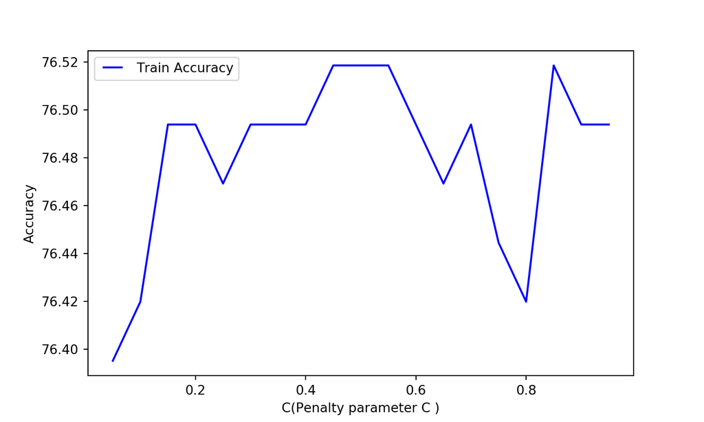

```python
line1, = plt.plot(C, train_results_svm, 'b', label="Train Accuracy") #blue
plt.legend(handler_map={line1: HandlerLine2D(numpoints=2)})
plt.ylabel("Accuracy")
plt.xlabel("C(Penalty parameter C )")
plt.show()
```

## Linear SVM Performance Evaluation

```python
from sklearn.metrics import confusion_matrix
from sklearn.metrics import precision_score
from sklearn.metrics import recall_score
from sklearn.metrics import classification_report
y_pred = model.predict(X_test_std)
cmnb=confusion_matrix(y_test, y_pred, labels=["tested_negative","tested_positive"])
target_names = ["tested_negative","tested_positive"]
print(classification_report(y_test, y_pred, target_names=target_names))
```

```
##                  precision    recall  f1-score   support
##
## tested_negative       0.79      0.90      0.84       146
## tested_positive       0.78      0.58      0.66        85
##
##        accuracy                           0.78       231
##       macro avg       0.78      0.74      0.75       231
##    weighted avg       0.78      0.78      0.78       231
```

## SVM with RBF Kernel Function: \(\gamma\)

```python
rbf_clf = svm.SVC()
gamma = [0.001,0.1,0.2,0.3,0.4,0.5,0.6,0.7,0.8,0.9,1]
train_results_svm =[]
train_results_svmC2 = []
train_results_svmC3= []
for n in gamma:
   model1 = SVC(C=0.1,kernel='rbf',gamma=n,cache_size=2000)
   model1.fit(X_train,y_train)
   acc = cross_val_score(model1, X_train_std, y_train, cv=bs).mean()*100
   train_results_svm.append(acc)
   model2 = SVC(C=0.5,kernel='rbf',gamma=n,cache_size=2000)
   acc2 = cross_val_score(model2, X_train_std, y_train, cv=bs).mean()*100
   train_results_svmC2.append(acc2)
   model3 = SVC(C=1,kernel='rbf',gamma=n,cache_size=2000)
   acc3 = cross_val_score(model3, X_train_std, y_train, cv=bs).mean()*100
   train_results_svmC3.append(acc3)
```

```
## SVC(C=0.1, cache_size=2000, class_weight=None, coef0=0.0,
##     decision_function_shape='ovr', degree=3, gamma=0.001, kernel='rbf',
##     max_iter=-1, probability=False, random_state=None, shrinking=True,
##     tol=0.001, verbose=False)
## SVC(C=0.1, cache_size=2000, class_weight=None, coef0=0.0,
##     decision_function_shape='ovr', degree=3, gamma=0.1, kernel='rbf',
##     max_iter=-1, probability=False, random_state=None, shrinking=True,
##     tol=0.001, verbose=False)
## SVC(C=0.1, cache_size=2000, class_weight=None, coef0=0.0,
##     decision_function_shape='ovr', degree=3, gamma=0.2, kernel='rbf',
##     max_iter=-1, probability=False, random_state=None, shrinking=True,
##     tol=0.001, verbose=False)
## SVC(C=0.1, cache_size=2000, class_weight=None, coef0=0.0,
##     decision_function_shape='ovr', degree=3, gamma=0.3, kernel='rbf',
##     max_iter=-1, probability=False, random_state=None, shrinking=True,
##     tol=0.001, verbose=False)
## SVC(C=0.1, cache_size=2000, class_weight=None, coef0=0.0,
##     decision_function_shape='ovr', degree=3, gamma=0.4, kernel='rbf',
##     max_iter=-1, probability=False, random_state=None, shrinking=True,
##     tol=0.001, verbose=False)
## SVC(C=0.1, cache_size=2000, class_weight=None, coef0=0.0,
##     decision_function_shape='ovr', degree=3, gamma=0.5, kernel='rbf',
##     max_iter=-1, probability=False, random_state=None, shrinking=True,
##     tol=0.001, verbose=False)
## SVC(C=0.1, cache_size=2000, class_weight=None, coef0=0.0,
##     decision_function_shape='ovr', degree=3, gamma=0.6, kernel='rbf',
##     max_iter=-1, probability=False, random_state=None, shrinking=True,
##     tol=0.001, verbose=False)
## SVC(C=0.1, cache_size=2000, class_weight=None, coef0=0.0,
##     decision_function_shape='ovr', degree=3, gamma=0.7, kernel='rbf',
##     max_iter=-1, probability=False, random_state=None, shrinking=True,
##     tol=0.001, verbose=False)
## SVC(C=0.1, cache_size=2000, class_weight=None, coef0=0.0,
##     decision_function_shape='ovr', degree=3, gamma=0.8, kernel='rbf',
##     max_iter=-1, probability=False, random_state=None, shrinking=True,
##     tol=0.001, verbose=False)
## SVC(C=0.1, cache_size=2000, class_weight=None, coef0=0.0,
##     decision_function_shape='ovr', degree=3, gamma=0.9, kernel='rbf',
##     max_iter=-1, probability=False, random_state=None, shrinking=True,
##     tol=0.001, verbose=False)
## SVC(C=0.1, cache_size=2000, class_weight=None, coef0=0.0,
##     decision_function_shape='ovr', degree=3, gamma=1, kernel='rbf', max_iter=-1,
##     probability=False, random_state=None, shrinking=True, tol=0.001,
##     verbose=False)
```

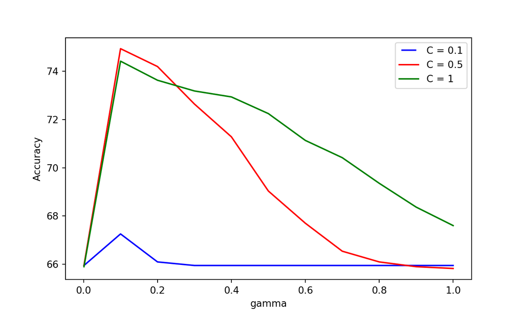

```python
line1, = plt.plot(gamma, train_results_svm, 'b', label="C = 0.1") #blue
line2, = plt.plot(gamma, train_results_svmC2, 'r', label="C = 0.5") #red
line3, = plt.plot(gamma, train_results_svmC3, 'g', label="C = 1") #green

plt.legend(handler_map={line1: HandlerLine2D(numpoints=3)})
plt.ylabel("Accuracy")
plt.xlabel("gamma")
plt.show()
```

## RBM Kernel SVM Performance

```python
param_grid = {'C':[0.5], 'gamma':[0.1]}
gridrbf = GridSearchCV(model2, param_grid, cv=bs)
gridrbf.fit(X_train_std, y_train)
```

```
## GridSearchCV(cv=ShuffleSplit(n_splits=25, random_state=0, test_size=0.3, train_size=None),
##              error_score='raise-deprecating',
##              estimator=SVC(C=0.5, cache_size=2000, class_weight=None, coef0=0.0,
##                            decision_function_shape='ovr', degree=3, gamma=1,
##                            kernel='rbf', max_iter=-1, probability=False,
##                            random_state=None, shrinking=True, tol=0.001,
##                            verbose=False),
##              iid='warn', n_jobs=None, param_grid={'C': [0.5], 'gamma': [0.1]},
##              pre_dispatch='2*n_jobs', refit=True, return_train_score=False,
##              scoring=None, verbose=0)
```

## RBM Kernel SVM Performance

```python
y_pred2 = gridrbf.predict(X_test_std)
cmnb2=confusion_matrix(y_test, y_pred2, labels=["tested_negative", "tested_positive"])
target_names = ["tested_negative", "tested_positive"]
print(classification_report(y_test, y_pred2, target_names=target_names))
```

```
##                  precision    recall  f1-score   support
##
## tested_negative       0.78      0.92      0.85       146
## tested_positive       0.81      0.55      0.66        85
##
##        accuracy                           0.79       231
##       macro avg       0.80      0.74      0.75       231
##    weighted avg       0.79      0.79      0.78       231
```